# Práctica 2: Limpieza y análisis de datos

Renán Freire, Manuel García

07/06/2021

# 1 Descripción del dataset

## 1.1 Descripción

Siguiendo la línea del deporte e inspirados en la película “Moneyball”, se ha encontrado un dataset llamado “Baseball Databank” (https://www.kaggle.com/open-source-sports/baseball-databank), que contiene una extensa base de datos sobre béisbol recopilada por el periodista Sean Lahman divididos en archivos planos (csv) y entre los más importantes se tiene:

- Master.csv: Contiene datos biográficos de los jugadores, como por ejemplo: Nombres, apellidos, lugar de nacimiento, año de nacimiento. Cada jugador tiene un identificado “playerID”.
- Batting.csv: Este archivo contiene datos estadísticos de bateo (corridas, homerun, número de golpes, etc).
- Pitching: Este archivo contiene datos estadísticos de lanzamiento (jugos ganados, perdidos, etc).
- Fielding.csv - Este archivo contiene datos estadísticos de las diferentes habilidades para moverse en el campo y atrapar, parar, lanzar, etc.
- Salaries.csv. Este archivo contiene el salario de cada jugador de acuerdo al año, equipo y liga jugada.

Cada registro de los datasets explicados están vinculado a un jugador mediante su identificador “playerID” además de otros identificadores relacionados a otros catálogos.

## 1.2 Importancia y Objetivo

Para esta práctica se ha centrado en el béisbol, debido a su importancia en el ámbito del BigData, ya que año tras año, este deporte genera gran cantidad de datos estadísticos en base a su complejidad, debido a sus diferentes reglas de juego y las diferentes características que cada jugador debe desempeñar de acuerdo a su posición en el campo de juego.

El objetivo para el cual usaremos los datos, está orientado a la predicción de los salarios de los bateadores y su dependencia con los datos de desempeño de cada jugador en la posición de bateo y las correspondientes estadísticas de campo en la posición fielding, generando modelos a través de algoritmos aprendizaje supervisado. Entre las preguntas a resolver tenemos:

- Se puede explicar el salario de los jugadores con los atributos técnicos?
- Existe una diferencia significativa entre los salarios de los jugadores nacidos en USA y los jugadores del Resto del Mundo?
- Ha variado la proporción de jugadores nacidos en el Resto del Mundo con respecto a los nacidos en USA a lo largo de los últimos 10 años.

# 2 Integración y selección de los datos de interés a analizar.

## 2.1 Integración de fuentes de datos

De acuerdo al análisis del conjunto de datos y a la problemática a resolver, planteada para esta práctica, vamos a trabajar con los datos biográficos de los jugadores que juegan en la posición de bateadores además de sus datos estadísticos de posición y campo, además de su salario. Para esto vamos a realizar una fusión horizontal y vertical de los archivos: master.csv, batting.csv, fielding.csv y salaries.csv.

- Para unir master.csv y batting.csv haremos uso del identificador “playerID” para la unión de los datos.
- Para unir el conjunto de datos resultante usamos los identificadores “yearID”, “stint”, “teamID”, “lgID” que vinculan otras claves primarias además del salario correspondiente.

```r
# Lectura de fuente de datos necesitadas
dataPlayer <- read.csv('../dataset/Master.csv')
print("[*] Dimensiones")
```

```
## [1] "[*] Dimensiones"
```

```r
dim(dataPlayer)
```

```
## [1] 18846    24
```

```r
print("[*] Nombre Columnas")
```

```
## [1] "[*] Nombre Columnas"
```

```r
colnames(dataPlayer)
```

```
##  [1] "playerID"     "birthYear"    "birthMonth"   "birthDay"     "birthCountry"
##  [6] "birthState"   "birthCity"    "deathYear"    "deathMonth"   "deathDay"
## [11] "deathCountry" "deathState"   "deathCity"    "nameFirst"    "nameLast"
## [16] "nameGiven"    "weight"       "height"       "bats"         "throws"
## [21] "debut"        "finalGame"    "retroID"      "bbrefID"
```

La fuente de datos **Master.csv** tiene las siguientes dimensiones: 18846 registros y 24 columnas.

```r
# Lectura de fuente de datos necesitadas
dataBatting <- read.csv('../dataset/Batting.csv')
print("[*] Dimensiones")
```

```
## [1] "[*] Dimensiones"
```

```r
dim(dataBatting)
```

```
## [1] 101332     22
```

```r
print("[*] Nombre Columnas")
```

```
## [1] "[*] Nombre Columnas"
```

```r
colnames(dataBatting)
```

```
##  [1] "playerID" "yearID"   "stint"    "teamID"   "lgID"     "G"
##  [7] "AB"       "R"        "H"        "X2B"      "X3B"      "HR"
## [13] "RBI"      "SB"       "CS"       "BB"       "SO"       "IBB"
## [19] "HBP"      "SH"       "SF"       "GIDP"
```

La fuente de datos **Batting.csv** tiene las siguientes dimensiones: 101332 registros y 22 columnas.

```r
# Lectura de fuente de datos necesitadas
dataFielding <- read.csv('../dataset/Fielding.csv')
print("[*] Dimensiones")
```

```
## [1] "[*] Dimensiones"
```

```r
dim(dataFielding)
```

```
## [1] 170526     18
```

```r
# Es necesario cambiar algunos nombres por coincidencia, les añadimos f.
names (dataFielding) = c("playerID", "yearID","stint","teamID", "lgID", "POS",
                         "f.G", "GS", "InnOuts","PO", "A", "E" , "DP", "PB",
                         "WP", "f.SB", "f.CS", "ZR")
print("[*] Nombre Columnas")
```

```
## [1] "[*] Nombre Columnas"
```

```r
colnames(dataFielding)
```

```
##  [1] "playerID" "yearID"   "stint"    "teamID"   "lgID"     "POS"
##  [7] "f.G"      "GS"       "InnOuts"  "PO"       "A"        "E"
## [13] "DP"       "PB"       "WP"       "f.SB"     "f.CS"     "ZR"
```

La fuente de datos **Fielding.csv** tiene las siguientes dimensiones: 170526 registros y 18 columnas.

```r
# Lectura de fuente de datos necesitadas
dataSalaries <- read.csv('../dataset/Salaries.csv')
print("[*] Dimensiones")
```

```
## [1] "[*] Dimensiones"
```

```r
dim(dataSalaries)
```

```
## [1] 25575     5
```

```r
print("[*] Nombre Columnas")
```

```
## [1] "[*] Nombre Columnas"
```

```r
colnames(dataSalaries)
```

```
## [1] "yearID"   "teamID"   "lgID"     "playerID" "salary"
```

La fuente de datos **Salaries.csv** tiene las siguientes dimensiones: 25575 registros y 5 columnas.

```r
# Integración fuentes
mergeCols2 <- c("playerID", "yearID", "teamID",   "lgID")
mergeCols3 <- c("playerID", "yearID", "stint", "teamID",   "lgID")

datasetBateadores <- merge(dataPlayer,dataSalaries,by="playerID")
datasetBateadores <- merge(datasetBateadores,dataFielding,by=mergeCols2)
datasetBateadores <- merge(datasetBateadores,dataBatting,by=mergeCols3)

print("[*] Dimensiones")
```

```
## [1] "[*] Dimensiones"
```

```r
dim(datasetBateadores)
```

```
## [1] 46836    59
```

```r
print("[*] Nombre Columnas")
```

```
## [1] "[*] Nombre Columnas"
```

```r
colnames(datasetBateadores)
```

```
##  [1] "playerID"     "yearID"       "stint"        "teamID"       "lgID"
##  [6] "birthYear"    "birthMonth"   "birthDay"     "birthCountry" "birthState"
## [11] "birthCity"    "deathYear"    "deathMonth"   "deathDay"     "deathCountry"
## [16] "deathState"   "deathCity"    "nameFirst"    "nameLast"     "nameGiven"
## [21] "weight"       "height"       "bats"         "throws"       "debut"
## [26] "finalGame"    "retroID"      "bbrefID"      "salary"       "POS"
## [31] "f.G"          "GS"           "InnOuts"      "PO"           "A"
## [36] "E"            "DP"           "PB"           "WP"           "f.SB"
## [41] "f.CS"         "ZR"           "G"            "AB"           "R"
## [46] "H"            "X2B"          "X3B"          "HR"           "RBI"
## [51] "SB"           "CS"           "BB"           "SO"           "IBB"
## [56] "HBP"          "SH"           "SF"           "GIDP"
```

El dataset final tiene las siguientes dimensiones: 46836 registros y 59 columnas.

```r
head(datasetBateadores)
```

```
##    playerID yearID stint teamID lgID birthYear birthMonth birthDay birthCountry
## 1 aardsda01   2004     1    SFN   NL      1981         12       27          USA
## 2 aardsda01   2007     1    CHA   AL      1981         12       27          USA
## 3 aardsda01   2008     1    BOS   AL      1981         12       27          USA
## 4 aardsda01   2009     1    SEA   AL      1981         12       27          USA
## 5 aardsda01   2010     1    SEA   AL      1981         12       27          USA
## 6 aardsda01   2012     1    NYA   AL      1981         12       27          USA
##   birthState birthCity deathYear deathMonth deathDay deathCountry deathState
## 1         CO    Denver        NA         NA       NA
## 2         CO    Denver        NA         NA       NA
## 3         CO    Denver        NA         NA       NA
## 4         CO    Denver        NA         NA       NA
## 5         CO    Denver        NA         NA       NA
## 6         CO    Denver        NA         NA       NA
##   deathCity nameFirst nameLast   nameGiven weight height bats throws      debut
```

[output cut: 20 more lines]

## 2.2 Selección de datos y reducción de dimensionalidad

Una vez analizado el dataset final, se puede identificar datos perdidos (N.D) para los años iniciales, por lo tanto, para nuestro objetivo, vamos a seleccionar todos los jugadores de posición bateadores a partir del año 1995, mejorando de alguna manera la calidad del conjunto de datos.

```r
# Selección de instancias a partir del año 1995
datasetBateadores.20 <- filter(datasetBateadores, yearID>=1995)
head(datasetBateadores.20)
```

```
##    playerID yearID stint teamID lgID birthYear birthMonth birthDay birthCountry
## 1 aardsda01   2004     1    SFN   NL      1981         12       27          USA
## 2 aardsda01   2007     1    CHA   AL      1981         12       27          USA
## 3 aardsda01   2008     1    BOS   AL      1981         12       27          USA
## 4 aardsda01   2009     1    SEA   AL      1981         12       27          USA
## 5 aardsda01   2010     1    SEA   AL      1981         12       27          USA
## 6 aardsda01   2012     1    NYA   AL      1981         12       27          USA
##   birthState birthCity deathYear deathMonth deathDay deathCountry deathState
## 1         CO    Denver        NA         NA       NA
## 2         CO    Denver        NA         NA       NA
## 3         CO    Denver        NA         NA       NA
## 4         CO    Denver        NA         NA       NA
## 5         CO    Denver        NA         NA       NA
## 6         CO    Denver        NA         NA       NA
##   deathCity nameFirst nameLast   nameGiven weight height bats throws      debut
```

[output cut: 20 more lines]

Como se observa en la sección anterior, el dataset contiene una gran cantidad de atributos, por lo tanto aplicamos la técnica de selección de subconjuntos de atributos para seleccionar datos de interés. Primeramente los atributos correspondientes a los datos biográficos de cada jugador, seleccionaremos manualmente, identificando cuales son más relevantes para nuestro estudio *(yearID, playerID, nameGiven, nameLast, birthCountry, bats, birthYear, debut)* y eliminaremos los siguientes atributos *(birthMonth , birthDay, birthState, birthCity, deathYear, deathMonth, deathDay, deathCountry, deathState, deathCity, weight, height, finalGame, retroID, bbrefID, stint, teamID, lgID)* que no aportan significado en nuestro análisis.

Los campos **birthYear** y **debut** son transformados a la edad del jugador de acuerdo al año de la observación y al número de años de experiencia del jugador respectivamente. Todo este proceso se presenta a continuación:

```r
# Transformar fecha debut en anios de experiencia
datasetBateadores.20$Exp<-datasetBateadores.20$yearID - as.numeric(format(as.Date(datasetBateadores.20$debut, format="%Y-%m-%d"),"%Y"))
# Transformar anio de nacimiento por edad
datasetBateadores.20$Edad<-datasetBateadores.20$yearID - datasetBateadores.20$birthYear
head(datasetBateadores.20)
```

```
##    playerID yearID stint teamID lgID birthYear birthMonth birthDay birthCountry
## 1 aardsda01   2004     1    SFN   NL      1981         12       27          USA
## 2 aardsda01   2007     1    CHA   AL      1981         12       27          USA
## 3 aardsda01   2008     1    BOS   AL      1981         12       27          USA
## 4 aardsda01   2009     1    SEA   AL      1981         12       27          USA
## 5 aardsda01   2010     1    SEA   AL      1981         12       27          USA
## 6 aardsda01   2012     1    NYA   AL      1981         12       27          USA
##   birthState birthCity deathYear deathMonth deathDay deathCountry deathState
## 1         CO    Denver        NA         NA       NA
## 2         CO    Denver        NA         NA       NA
## 3         CO    Denver        NA         NA       NA
## 4         CO    Denver        NA         NA       NA
## 5         CO    Denver        NA         NA       NA
## 6         CO    Denver        NA         NA       NA
##   deathCity nameFirst nameLast   nameGiven weight height bats throws      debut
```

[output cut: 20 more lines]

Después de este análisis, tenemos como resultado el siguiente dataset con los atributos necesitados:

```r
# Selección de atributos de interés para el dataset final
 datasetBateadores.20 <-select(datasetBateadores.20, "playerID", "yearID", "birthCountry",  "nameLast", "nameGiven",
                            "salary", "f.G", "InnOuts", "PO",  "A", "E", "DP", "G", "AB",  "R", "H", "X2B",
                            "X3B", "HR", "RBI", "SB",  "CS", "BB", "SO", "IBB", "HBP", "SH", "SF", "GIDP",
                            "Edad", "Exp" );
print("[*] Dimensiones")
```

```
## [1] "[*] Dimensiones"
```

```r
dim (datasetBateadores.20)
```

```
## [1] 32171    31
```

```r
head(datasetBateadores.20)
```

```
##    playerID yearID birthCountry nameLast   nameGiven  salary f.G InnOuts PO A E
## 1 aardsda01   2004          USA  Aardsma David Allan  300000  11      33  0 0 0
## 2 aardsda01   2007          USA  Aardsma David Allan  387500  25      96  2 4 1
## 3 aardsda01   2008          USA  Aardsma David Allan  403250  47     147  3 6 0
## 4 aardsda01   2009          USA  Aardsma David Allan  419000  73     213  2 5 0
## 5 aardsda01   2010          USA  Aardsma David Allan 2750000  53     150  2 3 1
## 6 aardsda01   2012          USA  Aardsma David Allan  500000   1       3  0 0 0
##   DP  G AB R H X2B X3B HR RBI SB CS BB SO IBB HBP SH SF GIDP Edad Exp
## 1  0 11  0 0 0   0   0  0   0  0  0  0  0   0   0  0  0    0   23   0
## 2  0 25  0 0 0   0   0  0   0  0  0  0  0   0   0  0  0    0   26   3
## 3  0 47  1 0 0   0   0  0   0  0  0  0  1   0   0  0  0    0   27   4
## 4  1 73  0 0 0   0   0  0   0  0  0  0  0   0   0  0  0    0   28   5
## 5  0 53  0 0 0   0   0  0   0  0  0  0  0   0   0  0  0    0   29   6
## 6  0  1  0 0 0   0   0  0   0  0  0  0  0   0   0  0  0    0   31   8
```

Con respecto a la selección de los atributos numéricos que representan a los datos estadísticos de rendimiento de un jugador, calcularemos los diferentes coeficientes de correlación entre parejas de variables, identificando cual de ellas están asociadas. Si existen parejas de variables con coeficientes de correlación superior al 85% descartamos una de las dos variables. A continuación se presenta la matriz de correlación y en base a dicha matriz la selección de atributos.

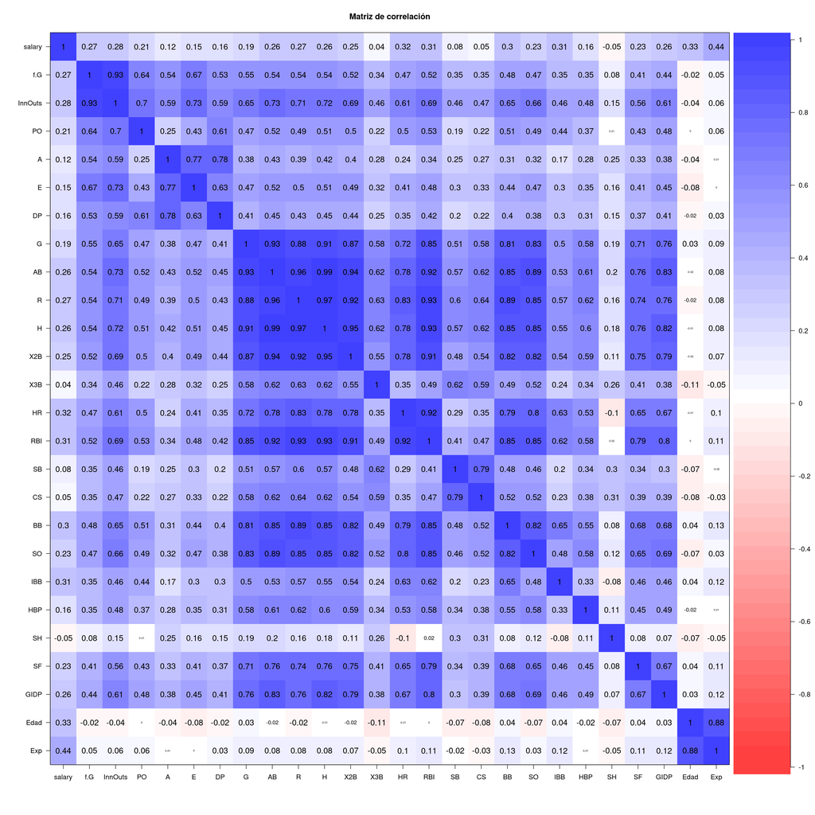

```r
library(psych)

corPlot(datasetBateadores.20[,6:31], cex = 0.8, main = "Matriz de correlación")
```

En base a la matriz de correlación se han identificado los siguientes atributos correlacionados fuertemente en base al coeficiente superior a 85% y que serán eliminados: f.G,H,G,R,X2B,RBI,BB,SO,Edad.

```r
# Selección de atributos de interés de datos de rendimiento
datasetBateadores.20 <-select(datasetBateadores.20,"playerID", "yearID", "birthCountry", "nameLast", "nameGiven","InnOuts","PO" ,  "A" ,"E" , "DP", "AB"  , "X3B" ,"HR" ,"SB" ,"CS" ,  "IBB" ,"HBP"  ,"SH", "SF", "GIDP", "Exp", "salary" );
head(datasetBateadores.20, n =10)
```

```
##     playerID yearID birthCountry nameLast        nameGiven InnOuts PO A E DP AB
## 1  aardsda01   2004          USA  Aardsma      David Allan      33  0 0 0  0  0
## 2  aardsda01   2007          USA  Aardsma      David Allan      96  2 4 1  0  0
## 3  aardsda01   2008          USA  Aardsma      David Allan     147  3 6 0  0  1
## 4  aardsda01   2009          USA  Aardsma      David Allan     213  2 5 0  1  0
## 5  aardsda01   2010          USA  Aardsma      David Allan     150  2 3 1  0  0
## 6  aardsda01   2012          USA  Aardsma      David Allan       3  0 0 0  0  0
## 7   abadfe01   2011         D.R.     Abad Fernando Antonio      60  1 2 2  0  0
## 8   abadfe01   2012         D.R.     Abad Fernando Antonio     138  3 6 0  0  7
## 9   abadfe01   2014         D.R.     Abad Fernando Antonio     171  0 8 0  0  0
## 10  abadfe01   2015         D.R.     Abad Fernando Antonio      NA  2 4 0  0  0
##    X3B HR SB CS IBB HBP SH SF GIDP Exp  salary
## 1    0  0  0  0   0   0  0  0    0   0  300000
## 2    0  0  0  0   0   0  0  0    0   3  387500
## 3    0  0  0  0   0   0  0  0    0   4  403250
## 4    0  0  0  0   0   0  0  0    0   5  419000
## 5    0  0  0  0   0   0  0  0    0   6 2750000
## 6    0  0  0  0   0   0  0  0    0   8  500000
## 7    0  0  0  0   0   0  0  0    0   1  418000
## 8    0  0  0  0   0   0  0  0    1   2  485000
## 9    0  0  0  0   0   0  0  0    0   4  525900
## 10   0  0  0  0   0   0  0  0    0   5 1087500
```

A continuación, se va a detallar cada uno de los atributos que contiene el dataset final.

- playerID: Identificador del jugador.
- yearID: Año de recopilación de datos de desempeño y salario.
- birthCountry: País de nacimiento del jugador.
- nameLast: Apellido del jugador.
- nameGiven: Nombre del jugador.
- InnOuts: Tiempo jugado por el jugador en el campo expresado en outs en su posición como Fielding.
- PO: número de veces que el jugador elimina a un corredor (out) en su posición como Fielding.
- A: número de asistencias durante un out en su posición como Fielding.
- E: Número de veces que el jugador erró al realizar una jugada en su posición como Fielding.
- DP: Número de dobles jugadas que participó el jugador en su posición como Fielding.
- AB: Número de veces que el jugador fue al bate en su posición como bateador.
- X3B: Número de veces que avanzó a tercera base el jugador en su posición como bateador.
- HR: Número de homerun en su posición como bateador.
- SB: Número de bases robadas por el jugador en su posición como bateador.
- CS: Número de eliminaciones por robar una base en su posición como bateador.
- IBB: Número de bases por bolas intencionales en su posición como bateador.
- HBP: Número de veces que fue golpeado por los lanzamientos de pitcher en su posición como bateador.
- SH: Números de sacrificios en su posición como bateador.
- SF: Número de vuelos de sacrificio en su posición como bateador.
- GIDP: Número de bateos para dobleplay en su posición como bateador.
- Exp: Anõs de experiencia desde su debut.
- Salary: Salario anual del jugador.

## 2.3 Tipos de variables

Después de haber seleccionado las observaciones y los atributos para el conjunto de datos a trabajar, se verificará los tipos de datos de las diferentes columnas que conforman en el dataset, mediante la función de R **str()**, como se ve a continuación:

```r
str(datasetBateadores.20)
```

```
## 'data.frame':    32171 obs. of  22 variables:
##  $ playerID    : chr  "aardsda01" "aardsda01" "aardsda01" "aardsda01" ...
##  $ yearID      : int  2004 2007 2008 2009 2010 2012 2011 2012 2014 2015 ...
##  $ birthCountry: chr  "USA" "USA" "USA" "USA" ...
##  $ nameLast    : chr  "Aardsma" "Aardsma" "Aardsma" "Aardsma" ...
##  $ nameGiven   : chr  "David Allan" "David Allan" "David Allan" "David Allan" ...
##  $ InnOuts     : int  33 96 147 213 150 3 60 138 171 NA ...
##  $ PO          : int  0 2 3 2 2 0 1 3 0 2 ...
##  $ A           : int  0 4 6 5 3 0 2 6 8 4 ...
##  $ E           : int  0 1 0 0 1 0 2 0 0 0 ...
##  $ DP          : int  0 0 0 1 0 0 0 0 0 0 ...
##  $ AB          : int  0 0 1 0 0 0 0 7 0 0 ...
##  $ X3B         : int  0 0 0 0 0 0 0 0 0 0 ...
##  $ HR          : int  0 0 0 0 0 0 0 0 0 0 ...
##  $ SB          : int  0 0 0 0 0 0 0 0 0 0 ...
##  $ CS          : int  0 0 0 0 0 0 0 0 0 0 ...
##  $ IBB         : int  0 0 0 0 0 0 0 0 0 0 ...
##  $ HBP         : int  0 0 0 0 0 0 0 0 0 0 ...
##  $ SH          : int  0 0 0 0 0 0 0 0 0 0 ...
##  $ SF          : int  0 0 0 0 0 0 0 0 0 0 ...
##  $ GIDP        : int  0 0 0 0 0 0 0 1 0 0 ...
##  $ Exp         : num  0 3 4 5 6 8 1 2 4 5 ...
##  $ salary      : int  300000 387500 403250 419000 2750000 500000 418000 485000 525900 1087500 ...
```

De acuerdo a la salida de esta función, tenemos que los datos de rendimiento y datos estadísticos de campo que se van a analizar son de tipo entero, listos para los análisis posteriores. Solo la variable Exp será transformada de numérica a entera.

```r
datasetBateadores.20$Exp <- as.integer(datasetBateadores.20$Exp)
head(datasetBateadores.20, n=10)
```

```
##     playerID yearID birthCountry nameLast        nameGiven InnOuts PO A E DP AB
## 1  aardsda01   2004          USA  Aardsma      David Allan      33  0 0 0  0  0
## 2  aardsda01   2007          USA  Aardsma      David Allan      96  2 4 1  0  0
## 3  aardsda01   2008          USA  Aardsma      David Allan     147  3 6 0  0  1
## 4  aardsda01   2009          USA  Aardsma      David Allan     213  2 5 0  1  0
## 5  aardsda01   2010          USA  Aardsma      David Allan     150  2 3 1  0  0
## 6  aardsda01   2012          USA  Aardsma      David Allan       3  0 0 0  0  0
## 7   abadfe01   2011         D.R.     Abad Fernando Antonio      60  1 2 2  0  0
## 8   abadfe01   2012         D.R.     Abad Fernando Antonio     138  3 6 0  0  7
## 9   abadfe01   2014         D.R.     Abad Fernando Antonio     171  0 8 0  0  0
## 10  abadfe01   2015         D.R.     Abad Fernando Antonio      NA  2 4 0  0  0
##    X3B HR SB CS IBB HBP SH SF GIDP Exp  salary
## 1    0  0  0  0   0   0  0  0    0   0  300000
## 2    0  0  0  0   0   0  0  0    0   3  387500
## 3    0  0  0  0   0   0  0  0    0   4  403250
## 4    0  0  0  0   0   0  0  0    0   5  419000
## 5    0  0  0  0   0   0  0  0    0   6 2750000
## 6    0  0  0  0   0   0  0  0    0   8  500000
## 7    0  0  0  0   0   0  0  0    0   1  418000
## 8    0  0  0  0   0   0  0  0    1   2  485000
## 9    0  0  0  0   0   0  0  0    0   4  525900
## 10   0  0  0  0   0   0  0  0    0   5 1087500
```

# 3 Limpieza de datos

## 3.1 Detección y tratamiento de valores perdidos

El dataset final, pese a descartar los primeros años, podemos verificar que aún existen datos perdidos o no definidos. Para esto, identificamos que campos contienen NA y vamos a imputarlos con el valor 0 indicando que para ese atributo no se tiene datos estadísticos recogidos.

```r
# Valores perdidos determinados por N.A
colSums(is.na(datasetBateadores.20))
```

```
##     playerID       yearID birthCountry     nameLast    nameGiven      InnOuts
##            0            0            0            0            0         7803
##           PO            A            E           DP           AB          X3B
##         6352         6352         6352         6352          533          533
##           HR           SB           CS          IBB          HBP           SH
##          533          533          533          533          533          533
##           SF         GIDP          Exp       salary
##          533          533            0            0
```

```r
# Reempalzar NA con valor 0
datasetBateadores.20$InnOuts[is.na(datasetBateadores.20$InnOuts)] <- 0
datasetBateadores.20$PO[is.na(datasetBateadores.20$PO)] <- 0
datasetBateadores.20$A[is.na(datasetBateadores.20$A)] <- 0
datasetBateadores.20$E[is.na(datasetBateadores.20$E)] <- 0
datasetBateadores.20$DP[is.na(datasetBateadores.20$DP)] <- 0
datasetBateadores.20$AB[is.na(datasetBateadores.20$AB)] <- 0
datasetBateadores.20$X3B[is.na(datasetBateadores.20$X3B)] <- 0
datasetBateadores.20$HR[is.na(datasetBateadores.20$HR)] <- 0
datasetBateadores.20$SB[is.na(datasetBateadores.20$SB)] <- 0
datasetBateadores.20$CS[is.na(datasetBateadores.20$CS)] <- 0
datasetBateadores.20$IBB[is.na(datasetBateadores.20$IBB)] <- 0
datasetBateadores.20$HBP[is.na(datasetBateadores.20$HBP)] <- 0
datasetBateadores.20$SH[is.na(datasetBateadores.20$SH)] <- 0
datasetBateadores.20$SF[is.na(datasetBateadores.20$SF)] <- 0
datasetBateadores.20$GIDP[is.na(datasetBateadores.20$GIDP)] <- 0
```

Verificamos que los NA efectivamente han sido reemplazados.

```r
# Valores perdidos determinados por N.A
colSums(is.na(datasetBateadores.20))
```

```
##     playerID       yearID birthCountry     nameLast    nameGiven      InnOuts
##            0            0            0            0            0            0
##           PO            A            E           DP           AB          X3B
##            0            0            0            0            0            0
##           HR           SB           CS          IBB          HBP           SH
##            0            0            0            0            0            0
##           SF         GIDP          Exp       salary
##            0            0            0            0
```

Una vez realizado este proceso, después de realizar una inspección al conjunto de datos, se ha identificado un caso especial, donde existen registros con valor 0 en las variables técnicas **InnOuts,PO ,A ,E,DP,AB, X3B, HR, SB, CS, IBB, HBP, SH, SF, GIDP** y la variable salario posee un valor. Este caso es un problema, debido a que una de nuestras preguntas iniciales consisten en determinar la relación del las variables de rendimiento con el valor del salario del jugador. Para solucionar esto, se va a implementar un proceso de imputación para estos valores 0 de todas las variables antes mencionadas mediante el algoritmo del vecino más cercano KNN.

El proceso consiste en los siguientes pasos:

- Asignar el valor *NA* a las variables de rendimiento con valor 0 cuyos registros cumplan la condición: InnOuts == 0 & PO == 0 & A == 0 & E == 0 & DP == 0 & AB == 0 & X3B == 0 & HR == 0 & SB == 0 & CS == 0 & IBB == 0 & HBP == 0 & SH == 0 & SF == 0 & GIDP == 0.
- Imputación de valores *NA* haciendo uso del modelo KNN, rellenando los valores *NA*, en base a las demás observaciones del dataset, promediando todos los puntos más cercanos.

Esta implementación se puede observar a continuación, que consta de la identificación del número de casos con datos de rendimiento en 0, además se inspecciona la variable salario ver si poseen valores en 0 y finalmente la imputación de valores de acuerdo a lo planteado.

```r
# Verificamos datos de salario en 0
dfSalarioCero <- filter(datasetBateadores.20, salary==0)

# Verificamos datos de rendimiento en 0
dfEstadisticasCero <- filter(datasetBateadores.20, InnOuts == 0 & PO == 0 & A == 0 & E == 0
                             & DP == 0 & AB==0 &  X3B == 0 & HR == 0 & SB == 0 & CS == 0
                             & IBB == 0 & HBP == 0 & SH == 0 & SF == 0 & GIDP == 0 )

# cosntruye dataframe de resultados
resultados <-data.frame(c(nrow(dfEstadisticasCero), nrow(dfSalarioCero)),c('DATOS RENDIMIENTO EN 0', 'DATOS SALARIOS EN 0'))
resultados <- setNames(resultados, c('Nro. Registros', 'Descripción'))
resultados
```

```
##   Nro. Registros            Descripción
## 1             25 DATOS RENDIMIENTO EN 0
## 2              0    DATOS SALARIOS EN 0
```

```r
# Obtener indices de los datos de rendimiento tengan todos 0
indicesFiltros <- which(datasetBateadores.20$InnOuts == 0 & datasetBateadores.20$PO == 0 &
                          datasetBateadores.20$A == 0 & datasetBateadores.20$E == 0 &
                          datasetBateadores.20$DP == 0 &  datasetBateadores.20$AB == 0 &
                          datasetBateadores.20$X3B == 0 &
                          datasetBateadores.20$HR == 0 & datasetBateadores.20$SB == 0 &
                          datasetBateadores.20$CS == 0 & datasetBateadores.20$IBB == 0 &
                          datasetBateadores.20$HBP == 0 & datasetBateadores.20$SH == 0 &
                          datasetBateadores.20$SF == 0 & datasetBateadores.20$GIDP == 0)

# Reemplazar valores de 0 por NA para los indices extraídos
datasetBateadores.20$InnOuts[indicesFiltros] <- NA
datasetBateadores.20$PO[indicesFiltros] <- NA
datasetBateadores.20$A[indicesFiltros] <- NA
datasetBateadores.20$E[indicesFiltros] <- NA
datasetBateadores.20$DP[indicesFiltros] <- NA
datasetBateadores.20$AB[indicesFiltros] <- NA
datasetBateadores.20$X3B[indicesFiltros] <- NA
datasetBateadores.20$HR[indicesFiltros] <- NA
datasetBateadores.20$SB[indicesFiltros] <- NA
datasetBateadores.20$CS[indicesFiltros] <- NA
datasetBateadores.20$IBB[indicesFiltros] <- NA
datasetBateadores.20$HBP[indicesFiltros] <- NA
datasetBateadores.20$SH[indicesFiltros] <- NA
datasetBateadores.20$SF[indicesFiltros] <- NA
datasetBateadores.20$GIDP[indicesFiltros] <- NA

# Verificamos valores NA
colSums(is.na(datasetBateadores.20))
```

```
##     playerID       yearID birthCountry     nameLast    nameGiven      InnOuts
##            0            0            0            0            0           25
##           PO            A            E           DP           AB          X3B
##           25           25           25           25           25           25
##           HR           SB           CS          IBB          HBP           SH
##           25           25           25           25           25           25
##           SF         GIDP          Exp       salary
##           25           25            0            0
```

```r
# Imputación de valores perdidos
datasetBateadores.20 <- kNN(datasetBateadores.20, k = 20)
head(datasetBateadores.20,n=10)
```

```
##     playerID yearID birthCountry nameLast        nameGiven InnOuts PO A E DP AB
## 1  aardsda01   2004          USA  Aardsma      David Allan      33  0 0 0  0  0
## 2  aardsda01   2007          USA  Aardsma      David Allan      96  2 4 1  0  0
## 3  aardsda01   2008          USA  Aardsma      David Allan     147  3 6 0  0  1
## 4  aardsda01   2009          USA  Aardsma      David Allan     213  2 5 0  1  0
## 5  aardsda01   2010          USA  Aardsma      David Allan     150  2 3 1  0  0
## 6  aardsda01   2012          USA  Aardsma      David Allan       3  0 0 0  0  0
## 7   abadfe01   2011         D.R.     Abad Fernando Antonio      60  1 2 2  0  0
## 8   abadfe01   2012         D.R.     Abad Fernando Antonio     138  3 6 0  0  7
## 9   abadfe01   2014         D.R.     Abad Fernando Antonio     171  0 8 0  0  0
## 10  abadfe01   2015         D.R.     Abad Fernando Antonio       0  2 4 0  0  0
##    X3B HR SB CS IBB HBP SH SF GIDP Exp  salary playerID_imp yearID_imp
## 1    0  0  0  0   0   0  0  0    0   0  300000        FALSE      FALSE
## 2    0  0  0  0   0   0  0  0    0   3  387500        FALSE      FALSE
## 3    0  0  0  0   0   0  0  0    0   4  403250        FALSE      FALSE
```

[output cut: 40 more lines]

La función utilizada para imputar valores adiciona al dataset unas nuevas columnas de tipo booleanas indicando true o false para el proceso KNN. Por lo tanto, eliminaremos estas columnas de nuestra dataset final.

```r
# Eliminar columnas agregagdas por el método KNN usado para imputación
 datasetBateadores.20 <- datasetBateadores.20[ -c(23:44) ]
 head(datasetBateadores.20, n=15)
```

```
##     playerID yearID birthCountry nameLast        nameGiven InnOuts  PO A E DP
## 1  aardsda01   2004          USA  Aardsma      David Allan      33   0 0 0  0
## 2  aardsda01   2007          USA  Aardsma      David Allan      96   2 4 1  0
## 3  aardsda01   2008          USA  Aardsma      David Allan     147   3 6 0  0
## 4  aardsda01   2009          USA  Aardsma      David Allan     213   2 5 0  1
## 5  aardsda01   2010          USA  Aardsma      David Allan     150   2 3 1  0
## 6  aardsda01   2012          USA  Aardsma      David Allan       3   0 0 0  0
## 7   abadfe01   2011         D.R.     Abad Fernando Antonio      60   1 2 2  0
## 8   abadfe01   2012         D.R.     Abad Fernando Antonio     138   3 6 0  0
## 9   abadfe01   2014         D.R.     Abad Fernando Antonio     171   0 8 0  0
## 10  abadfe01   2015         D.R.     Abad Fernando Antonio       0   2 4 0  0
## 11 abbotje01   1998          USA   Abbott  Jeffrey William    1526 132 0 4  0
## 12 abbotje01   1998          USA   Abbott  Jeffrey William     794  71 0 3  0
## 13 abbotje01   1998          USA   Abbott  Jeffrey William      90  10 0 0  0
## 14 abbotje01   1998          USA   Abbott  Jeffrey William       0   0 0 0  0
```

[output cut: 17 more lines]

Una vez realizado la limpieza de datos, se ha descubierto que para ciertos jugadores del datastet tienen más de un registro para el mismo año, de acuerdo a la documentación de Sea Lahman, estos datos se presentan de esa forma ya que corresponden a los datos estadísticos de un jugador que estuvo en diferentes equipos o ligas para el mismo año. Para solucionar esto, se va a fusionar los registros de ese jugador en una sola fila y los datos estadísticos de rendimiento y datos de campo tendrán la suma de sus valores y para los años de experiencia y salario, como sus valores son iguales en los dos registros, solamente se escoge uno de ellos.

```r
# Se agrupan registros para el mismo jugador calculando la media de los datos estadisticos
datasetBateadores.20 <- aggregate(cbind(InnOuts,PO ,A, E, DP, AB, X3B, HR,SB,CS,IBB,HBP,SH, SF, GIDP) ~ yearID
                                  + playerID +   nameLast +  birthCountry + Exp + salary, data = datasetBateadores.20, FUN = sum)
# Ordenar por idJugador
datasetBateadores.20 <- datasetBateadores.20[order(datasetBateadores.20$playerID),]
head(datasetBateadores.20, n=15)
```

```
##       yearID  playerID nameLast birthCountry Exp  salary InnOuts  PO  A E DP
## 2938    2004 aardsda01  Aardsma          USA   0  300000      33   0  0 0  0
## 4535    2007 aardsda01  Aardsma          USA   3  387500      96   2  4 1  0
## 5129    2008 aardsda01  Aardsma          USA   4  403250     147   3  6 0  0
## 5566    2009 aardsda01  Aardsma          USA   5  419000     213   2  5 0  1
## 6845    2012 aardsda01  Aardsma          USA   8  500000       3   0  0 0  0
## 12402   2010 aardsda01  Aardsma          USA   6 2750000     150   2  3 1  0
## 5531    2011  abadfe01     Abad         D.R.   1  418000      60   1  2 2  0
## 6382    2012  abadfe01     Abad         D.R.   2  485000     138   3  6 0  0
## 7606    2014  abadfe01     Abad         D.R.   4  525900     171   0  8 0  0
## 9759    2015  abadfe01     Abad         D.R.   5 1087500       0   2  4 0  0
## 1145    1998 abbotje01   Abbott          USA   1  175000    3052 264  0 8  0
## 2614    1999 abbotje01   Abbott          USA   2  255000     816  50  0 2  0
## 2621    2000 abbotje01   Abbott          USA   3  255000    1356 101  2 2  0
## 3087    2001 abbotje01   Abbott          USA   4  300000     258  26  0 1  0
```

[output cut: 17 more lines]

## 3.2 Identificación y tratamiento de valores extremos.

Para nuestro dataset final vamos a identificar si existen valores extremos sobre las variables de tipo numérico, mediante gráficas de caja y bigote para cada variable implicada. A continuación se presentan las gŕaficas y los resultados obtenidos.

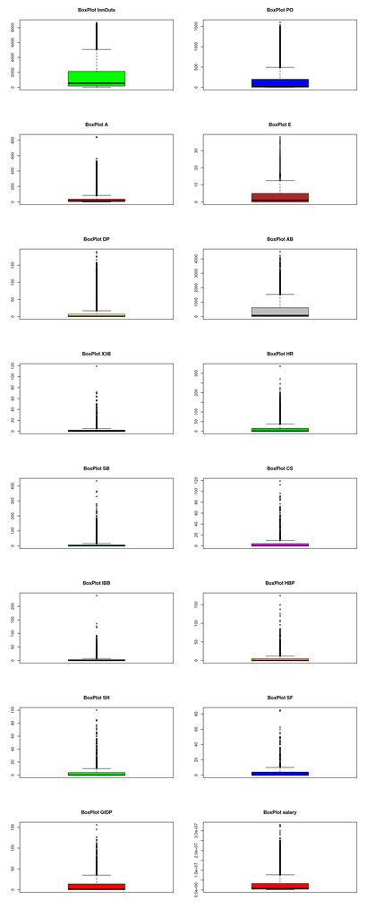

```r
 par(mfrow=c(8,2))
 boxplot(datasetBateadores.20$InnOuts, main="BoxPlot InnOuts", col="green")
 outliersInnOuts <- boxplot.stats(datasetBateadores.20$InnOuts)$out

 boxplot(datasetBateadores.20$PO, main="BoxPlot PO", col="blue")
 outliersPO <- boxplot.stats(datasetBateadores.20$PO)$out

 boxplot(datasetBateadores.20$A, main="BoxPlot A", col="red")
 outliersA <- boxplot.stats(datasetBateadores.20$A)$out

 boxplot(datasetBateadores.20$E, main="BoxPlot E", col="brown")
 outliersE <- boxplot.stats(datasetBateadores.20$E)$out

 boxplot(datasetBateadores.20$DP, main="BoxPlot DP", col="yellow")
 outliersDP <- boxplot.stats(datasetBateadores.20$DP)$out

 boxplot(datasetBateadores.20$AB, main="BoxPlot AB", col="gray")
 outliersAB <- boxplot.stats(datasetBateadores.20$AB)$out

 boxplot(datasetBateadores.20$X3B, main="BoxPlot X3B", col="black")
 outliersX3B <- boxplot.stats(datasetBateadores.20$X3B)$out

 boxplot(datasetBateadores.20$HR, main="BoxPlot HR", col="green3")
 outliersHR <- boxplot.stats(datasetBateadores.20$HR)$out

 boxplot(datasetBateadores.20$SB, main="BoxPlot SB", col="cyan")
 outliersSB <- boxplot.stats(datasetBateadores.20$SB)$out

 boxplot(datasetBateadores.20$CS, main="BoxPlot CS", col="magenta")
 outliersCS <- boxplot.stats(datasetBateadores.20$CS)$out

 boxplot(datasetBateadores.20$IBB, main="BoxPlot IBB", col="pink")
 outliersIBB <- boxplot.stats(datasetBateadores.20$IBB)$out

 boxplot(datasetBateadores.20$HBP, main="BoxPlot HBP", col="orange")
 outliersHBP <- boxplot.stats(datasetBateadores.20$HBP)$out

 boxplot(datasetBateadores.20$SH, main="BoxPlot SH", col="green")
 outliersSH <- boxplot.stats(datasetBateadores.20$SH)$out

 boxplot(datasetBateadores.20$SF, main="BoxPlot SF", col="blue")
 outliersSF <- boxplot.stats(datasetBateadores.20$SF)$out

 boxplot(datasetBateadores.20$GIDP, main="BoxPlot GIDP", col="red")
 outliersGIDP <- boxplot.stats(datasetBateadores.20$GIDP)$out

 boxplot(datasetBateadores.20$salary, main="BoxPlot salary", col="red")
```

```r
 outliersSalary <- boxplot.stats(datasetBateadores.20$salary)$out
```

De acuerdo a los gráficos, podemos identificar el número de valores atípicos para cada atributo.

```r
resultadosOutliersDF <-data.frame(c(length(outliersInnOuts),
                                    length(outliersPO),
                                    length(outliersA),
                                    length(outliersE),
                                    length(outliersDP),
                                    length(outliersAB),
                                    length(outliersX3B),
                                    length(outliersHR),
                                    length(outliersSB),
                                    length(outliersCS),
                                    length(outliersIBB),
                                    length(outliersHBP),
                                    length(outliersSH),
                                    length(outliersSF),
                                    length(outliersGIDP),
                                    length(outliersSalary)
                                    ),
                        c('VARIABLE InnOuts',
                          'VARIABLE PO',
                          'VARIABLE A',
                          'VARIABLE E',
                          'VARIABLE DP',
                          'VARIABLE AB',
                          'VARIABLE X3B',
                          'VARIABLE HR',
                          'VARIABLE SB',
                          'VARIABLE CS',
                          'VARIABLE IBB',
                          'VARIABLE HBP',
                          'VARIABLE SH',
                          'VARIABLE SF',
                          'VARIABLE GIDP',
                          'VARIABLE Salary'
                          )
                        )
resultadosOutliersDF <- setNames(resultadosOutliersDF, c('Nro. Valores Atípicos', 'Variable'))
resultadosOutliersDF
```

```
##    Nro. Valores Atípicos         Variable
## 1                    312 VARIABLE InnOuts
## 2                   1477      VARIABLE PO
## 3                   2769       VARIABLE A
## 4                   1115       VARIABLE E
## 5                   3244      VARIABLE DP
## 6                   1056      VARIABLE AB
## 7                   2659     VARIABLE X3B
## 8                   1945      VARIABLE HR
## 9                   2651      VARIABLE SB
## 10                  1812      VARIABLE CS
## 11                  2280     VARIABLE IBB
## 12                  1656     VARIABLE HBP
## 13                  1475      VARIABLE SH
## 14                  1783      VARIABLE SF
## 15                  1110    VARIABLE GIDP
## 16                  1608  VARIABLE Salary
```

Con esto hemos concluido con la fase de pre-procesamiento de los datos. A continuación se examina la dimensión total del dataset final.

```r
# Dataset final
dim(datasetBateadores.20)
```

```
## [1] 17440    21
```

# 4 Análisis de los datos.

## 4.1 Selección de los grupos de datos que se quieren analizar/comparar

Para nuestros análisis posteriores, seleccionamos seleccionamos las siguientes muestras.

### 4.1.1 Selección de jugadores para visualizaciones

Creamos el campo Nacionalidad y realizamos algunas agrupaciones que nos convienen para las representaciones posteriores.

```r
nacionalidad <- vector() # Se crea un vector vacío
nacionalidad[datasetBateadores.20$birthCountry=='USA'] <- 'USA'
nacionalidad[datasetBateadores.20$birthCountry!='USA'] <- 'RM'
datasetBateadores.20$nacionalidad <- nacionalidad

datasetBateadores.M2000 <- filter(datasetBateadores.20, yearID>=2000)
datasetBateadores.2000 <- filter(datasetBateadores.20, yearID>=2000)
datasetBateadores.2015 <- filter(datasetBateadores.20, yearID>=2015)
```

### 4.1.2 Selección de datos para Hipótesis de Contraste sobre el salario

En este caso realizamos una selección que nos sirva para contrastar si el salario de los jugadores de USA es significativamente diferente al de los jugadores del Resto del Mundo RM en el año 2015

```r
# Seleccionamos los jugadores del 2015
datasetBateadores.2015 <- filter(datasetBateadores.20, yearID==2015)

# Creamos las muestras de jugadores de USA y RM para 2015 basandones en el datasetBateadores.2015
bat.usa <-datasetBateadores.2015 %>%
  filter(birthCountry =='USA')
bat.rm <-datasetBateadores.2015 %>%
  filter(birthCountry !='USA')

# dimensiones
dim(bat.usa)
```

```
## [1] 589  22
```

```r
dim(bat.rm)
```

```
## [1] 221  22
```

```r
# Vista de los datos
head(bat.usa)
```

```
##   yearID  playerID nameLast birthCountry Exp  salary InnOuts  PO   A  E DP  AB
## 1   2015 ackledu01   Ackley          USA   4 2600000       0 102   6  0  1 930
## 2   2015 adamsau01    Adams          USA   1  507700       0   0   4  0  0   1
## 3   2015 adamsma01    Adams          USA   3  534000       0 321  32  3 30 175
## 4   2015 affelje01  Affeldt          USA  13 6000000       0   3   6  0  0   2
## 5   2015 ahmedni01    Ahmed          USA   1  508500       0 190 368 13 84 421
## 6   2015 alberma01   Albers          USA   9 1500000       0   3   8  1  1   0
##   X3B HR SB CS IBB HBP SH SF GIDP nacionalidad
## 1   5 30 10 10   0   5 15 15   15          USA
## 2   0  0  0  0   0   0  0  0    1          USA
## 3   0  5  1  0   1   0  0  1    1          USA
## 4   0  0  0  0   0   0  0  0    0          USA
## 5   6  9  4  5   1   1  5  3    4          USA
## 6   0  0  0  0   0   0  0  0    0          USA
```

```r
head(bat.rm)
```

```
##   yearID  playerID     nameLast birthCountry Exp  salary InnOuts  PO   A  E  DP
## 1   2015  abadfe01         Abad         D.R.   5 1087500       0   2   4  0   0
## 2   2015 abreujo02        Abreu         Cuba   1 8666000       0 952  60 11 100
## 3   2015 albural01 Alburquerque         D.R.   4 1725000       0   5   9  0   2
## 4   2015 alcanar01    Alcantara         D.R.   1  510000       0  15  19  1   2
## 5   2015 alonsyo01       Alonso         Cuba   5 1650000       0 817  56  3  71
## 6   2015 altuvjo01       Altuve    Venezuela   4 2500000       0 247 417  5  81
##    AB X3B HR SB CS IBB HBP SH SF GIDP nacionalidad
## 1   0   0  0  0  0   0   0  0  0    0           RM
## 2 613   3 30  0  0  11  15  0  1   16           RM
## 3   0   0  0  0  0   0   0  0  0    0           RM
## 4  52   0  0  2  0   0   0  2  0    0           RM
## 5 708   2 10  4 10   6   6  0  6   26           RM
## 6 638   4 15 38 13   8   9  3  6   17           RM
```

### 4.1.3 Selección de datos para Regresión lineal sobre el salario

Pensamos que los indicadores sobre el juego de los diferenes jugadores pueden determinar su salario, para ello, vamos a realizar una selección de todos los jugadores que tienen salario en 2015 calculando la suma de sus indicadores durante su carrera y a estos datos, le añadimos la experiencia y el salario de cada jugador en el 2015.

```r
# Realizamos una primera selección con los indicadores de juego.
datasetBateadores.group <-  datasetBateadores.20 %>%
  select(playerID,InnOuts,PO ,A ,E,DP,AB, X3B, HR, SB, CS, IBB, HBP, SH, SF, GIDP)

# Realizamos la suma de los indicadores por jugador
datasetBateadores.group <-  datasetBateadores.group%>%
  replace(is.na(.), 0) %>%
  group_by(playerID) %>%
  summarise_all(funs(sum))

# Obtenemos la experiencia de los jugadores en 2015
experiencia <-  datasetBateadores.20%>%
  filter(yearID==2015) %>%
  select(playerID,Exp)

# Obtenemos el salario de los jugadores en 2015
dataSalaries2015<-datasetBateadores.20%>%
  filter(yearID==2015)%>%
  select(playerID,salary)

# Integramos los datos de los jugadores con el salario
datasetBateadores.lm <- merge(datasetBateadores.group,dataSalaries2015,by="playerID")

# Integramos los datos de los jugadores + Salario con la Experiencia
datasetBateadores.lm <-
merge(datasetBateadores.lm ,experiencia,by="playerID")

# Mostramos los datos finales para la Regresión
head(datasetBateadores.lm)
```

```
##    playerID InnOuts   PO   A  E  DP   AB X3B  HR SB CS IBB HBP SH SF GIDP
## 1  abadfe01     369    6  20  2   0    7   0   0  0  0   0   0  0  0    1
## 2 abreujo02    2871 1922 129 17 205 1169   5  66  3  1  26  26  0  5   30
## 3 ackledu01   10191 1107 564 13 132 5068  27 102 62 39  21  16 43 26   71
## 4 adamsau01       0    0   4  0   0    1   0   0  0  0   0   0  0  0    1
## 5 adamsma01    5283 2034 162 14 211  998   5  37  4  3   6   3  0  8   19
## 6 affelje01    2589   44 177 13  12   16   0   0  0  0   0   0  0  0    0
##    salary Exp
## 1 1087500   5
## 2 8666000   1
## 3 2600000   4
## 4  507700   1
## 5  534000   3
## 6 6000000  13
```

### 4.1.4 Selección de datos para Proporción entre jugadores USA y jugadores RM

En este caso queremos comprobar mediante hipótesis de contraste, si las proporciones de jugadores no nacidos en USA cambió entre el año 2000 y el año 2015.

```r
# Seleccionamos los jugadores del 2000
datasetBateadores.2000 <- filter(datasetBateadores.20, yearID==2000)

# Creamos las muestras de jugadores de USA y RM para 2000
bat.usa.2000 <-datasetBateadores.2000 %>%
  filter(birthCountry =='USA')
bat.rm.2000 <-datasetBateadores.2000 %>%
  filter(birthCountry !='USA')

# dimensiones 2000

dim(bat.usa.2000)
```

```
## [1] 610  22
```

```r
dim(bat.rm.2000)
```

```
## [1] 183  22
```

```r
# Vista de los datos 2000

head(bat.usa.2000)
```

```
##   yearID  playerID nameLast birthCountry Exp  salary InnOuts  PO   A E DP   AB
## 1   2000 abbotje01   Abbott          USA   3  255000    1356 101   2 2  0  860
## 2   2000 abbotku01   Abbott          USA   7  500000    1122  74 105 7 13  785
## 3   2000 abbotpa01   Abbott          USA  10  285000     537  12  19 1  3    5
## 4   2000 adamste01    Adams          USA   5 1400000     252  14  21 2  0    2
## 5   2000 agbaybe01 Agbayani          USA   2  220000    2325 155   3 4  0 1400
## 6   2000 aguilri01 Aguilera          USA  15 3500000     144   6   7 0  0    0
##   X3B HR SB CS IBB HBP SH SF GIDP nacionalidad
## 1   4 12  8  4   4   8  8  4    8          USA
## 2   5 30  5  5  10   5  0  5   10          USA
## 3   0  0  0  0   0   0  1  0    0          USA
## 4   0  0  0  0   0   0  1  0    0          USA
## 5   4 60 20 20   8  28  0 12   24          USA
## 6   0  0  0  0   0   0  0  0    0          USA
```

```r
head(bat.rm.2000)
```

```
##   yearID  playerID  nameLast birthCountry Exp  salary InnOuts  PO   A  E DP
## 1   2000 abreubo01     Abreu    Venezuela   4 2933333    3993 337  13  4  2
## 2   2000 aceveju01   Acevedo       Mexico   5  612500     249   8   8  0  0
## 3   2000 alexama02 Alexander         D.R.   8  612500    1524  60 119  7 13
## 4   2000 alfonan01 Alfonseca         D.R.   3  380000     210   1  14  1  1
## 5   2000 alfoned01   Alfonzo    Venezuela   5 4225000    3723 316 362 10 84
## 6   2000 alicelu01    Alicea         P.R.  12  750000    3294 253 328 18 86
##     AB X3B HR SB CS IBB HBP SH SF GIDP nacionalidad
## 1 1152  20 50 56 16  18   2  0  6   24           RM
## 2    1   0  0  0  0   0   0  0  0    0           RM
## 3  582   9 12  6  0   0   0  6  0    0           RM
## 4    0   0  0  0  0   0   0  0  0    0           RM
## 5  544   2 25  3  2   1   5  0  6   12           RM
## 6 1620  24 18  3  9   3  15 21 21   39           RM
```

## 4.2 Comprobación de la normalidad y homogeneidad de la varianza.

### 4.2.1 Comprobación de la normalidad

Podemos ver que los datos de nuestros atributos no siguen una distribución normal.

```r
# Comprobamos la normalidad de los diferentes campos mediante el test de Shapiro
alpha = 0.05
columns = colnames(datasetBateadores.lm[,2:18])
print(columns)
```

```
##  [1] "InnOuts" "PO"      "A"       "E"       "DP"      "AB"      "X3B"
##  [8] "HR"      "SB"      "CS"      "IBB"     "HBP"     "SH"      "SF"
## [15] "GIDP"    "salary"  "Exp"
```

```r
    for (i in 2:18) {
      #print(i)
         if (is.integer(datasetBateadores.lm[,i]) |    is.numeric(datasetBateadores.lm[,i])) {
            p_val = shapiro.test(datasetBateadores.lm[,i])$p.value
            if (p_val < alpha) {
               print(columns[i-1])
                 }
             }
     }
```

```
## [1] "InnOuts"
## [1] "PO"
## [1] "A"
## [1] "E"
## [1] "DP"
## [1] "AB"
## [1] "X3B"
## [1] "HR"
## [1] "SB"
## [1] "CS"
## [1] "IBB"
## [1] "HBP"
## [1] "SH"
## [1] "SF"
## [1] "GIDP"
## [1] "salary"
## [1] "Exp"
```

Podemos ver que todas son sesgadas a la derecha, esto es debido a que son indicadores de rendimiento y de salario y por tanto solo algunos jugadores tienen valores altos de ambos y esto hace que la cola a la derecha se extienda mucho, lo podemos observar representando las distribuciones:

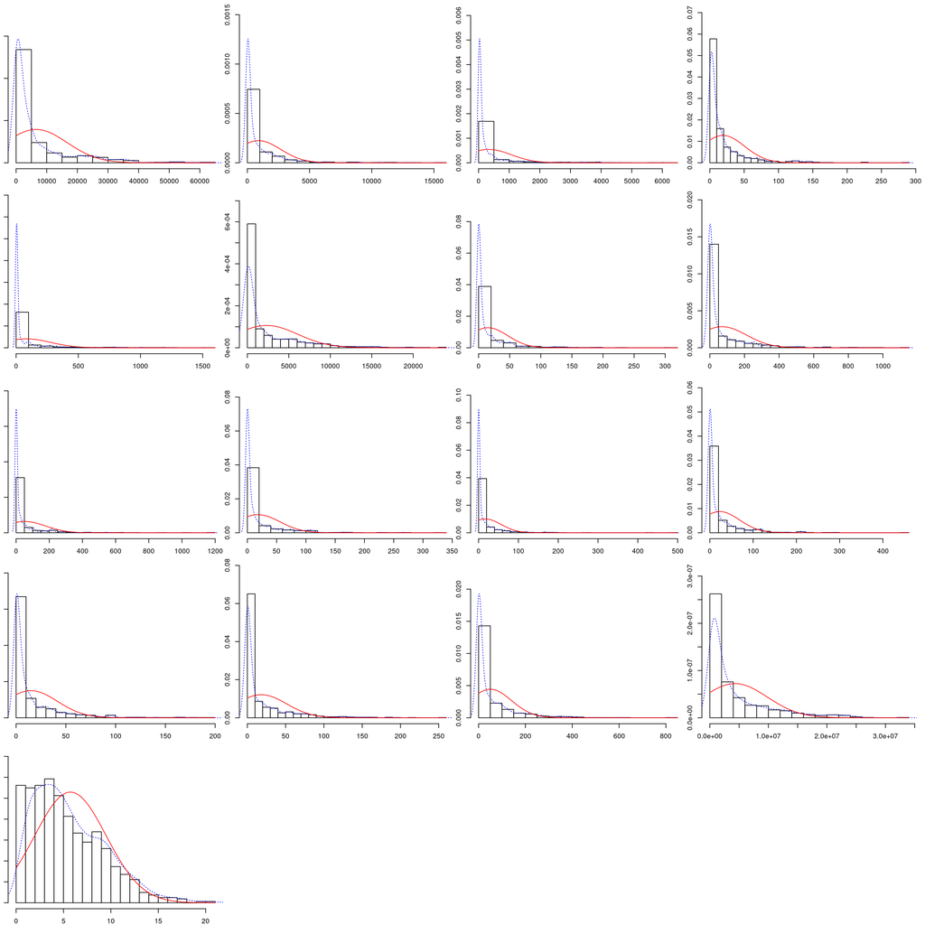

```r
multi.hist(x = datasetBateadores.lm[,2:18], dcol = c("blue", "red"), dlty = c("dotted", "solid"),
           main = "")
```

### 4.2.2 homogeneidad de la varianza

Ahora comprobaremos la varianza de las muestras entre jugadores de EEUU y Resto del mundo para comprobar si las muestras presentan homoscedasticidad

```r
# tes de homocedastecidad F

var.test(x = bat.usa$salary,
         y = bat.rm$salary)
```

```
##
##  F test to compare two variances
##
## data:  bat.usa$salary and bat.rm$salary
## F = 1.0088, num df = 588, denom df = 220, p-value = 0.951
## alternative hypothesis: true ratio of variances is not equal to 1
## 95 percent confidence interval:
##  0.805496 1.249480
## sample estimates:
## ratio of variances
##            1.00881
```

Por los resultados podemos decir que existe homocedasticidad, las varianzas de las dos muestras son iguales.

## 4.3 Aplicación de pruebas estadísticas para comparar los grupos de datos.

### 4.3.1 Hipótesis de Contraste sobre el salario

Queremos responder a la pregunta siguiente:

**¿Es la media de Salario de los jugadores nacidos en USA, mayor que la media salarial de los jugadores nacidos en el Resto del Mundo?**

• Hipótesis nula: la media del salario de los jugadores de USA es igual que el salario de los jugadores del Resto del Mundo.

• Hipótesis alternativa: la media del salario de los jugadores de USA es mayor que el salario de los jugadores del Resto del Mundo.

$$\left\{
\begin{array}{ll}
\thinspace Hipótesis\thinspace nula\hspace{31pt} H_{0}: & \mu_{USA}-\mu_{RM} =0\\
\thinspace Hipótesis\thinspace alternativa\thinspace H_{1}: & \mu_{USA}-\mu_{RM} >0
\end{array}
\right.$$

Llevaremos a cabo un test de contraste unilateral para la media de los salarios para dos muestras poblacionales independientes, con varianza desconocida, una con los jugadores nacidos en USA y otra con los jugadores del Resto del Mundo.

Por el tamaño de las muestras asumiremos normalidad en la distribución de las variables y ya comprobamos que no podemos desestimar homoscedasticidad en el test F que hemos realizado en el apartado anterior.

Para nuestro caso en el que las varianzas son desconocidas pero iguales, el estadístico de contraste sera:

$$t_{n_L+n_R-2}=\frac{\bar{X}_L-\bar{X}_R}{S\sqrt{\frac{1}{n_L}+\frac{1}{n_R}}}$$
El cual sigue una distribución t Student con $n_L+n_R-2$ grados de libertad y donde $S$ viene dado por:

$$S=\sqrt{\frac{{(n_L-1)\tilde{S}^2_L+(n_R-1)\tilde{S}^2_R}}{n_L+n_R-2}}$$
Aplicamos el test t

```r
t.test(bat.usa$salary,bat.rm$salary,alternative="greater", var.equal=TRUE)
```

```
##
##  Two Sample t-test
##
## data:  bat.usa$salary and bat.rm$salary
## t = -0.60902, df = 808, p-value = 0.7287
## alternative hypothesis: true difference in means is greater than 0
## 95 percent confidence interval:
##  -981423.3       Inf
## sample estimates:
## mean of x mean of y
##   4223363   4488333
```

Como vemos no podemos desestimar la hipótesis nula y concluimos que el salario medio de los jugadores nacidos en USA es igual al salario medio de los jugadores no nacidos en USA.

### 4.3.2 Regresión lineal sobre el salario

Vamos a generar un modelo de regresión lineal multivarible con el obejtivo de que la variable dependiente Salary, pueda ser explicada por las variables independientes determinadas por los atributos técnicos de los jugadores.

Para ello y tras varios intentos, donde hemos alternado diferentes variables, hemos desestimado aquellas que no tenian coeficientes significativos y ademas, hemos calculado los coeficientes para el log del salario y hemos encotrado que tambien mejora el modelo la función polinómica en la variable InnOuts.

```r
modelo.salary=lm(log10(salary)~poly(InnOuts, 2)+PO+A+AB+HR+IBB+SH+Exp,data=datasetBateadores.lm)

summary(modelo.salary)
```

```
##
## Call:
## lm(formula = log10(salary) ~ poly(InnOuts, 2) + PO + A + AB +
##     HR + IBB + SH + Exp, data = datasetBateadores.lm)
##
## Residuals:
##     Min      1Q  Median      3Q     Max
## -1.3827 -0.2247 -0.0725  0.2265  1.4980
##
## Coefficients:
##                     Estimate Std. Error t value Pr(>|t|)
## (Intercept)        6.092e+00  4.510e-02 135.082  < 2e-16 ***
## poly(InnOuts, 2)1  1.057e+01  1.326e+00   7.973 5.32e-15 ***
## poly(InnOuts, 2)2 -4.651e+00  4.064e-01 -11.446  < 2e-16 ***
## PO                -5.524e-05  1.292e-05  -4.274 2.15e-05 ***
## A                 -9.203e-05  2.831e-05  -3.250  0.00120 **
## AB                -8.608e-05  1.195e-05  -7.204 1.35e-12 ***
## HR                 1.065e-03  2.389e-04   4.458 9.46e-06 ***
## IBB                1.931e-03  6.217e-04   3.106  0.00196 **
## SH                 1.607e-03  7.127e-04   2.255  0.02443 *
## Exp                6.219e-02  4.404e-03  14.123  < 2e-16 ***
## ---
## Signif. codes:  0 '***' 0.001 '**' 0.01 '*' 0.05 '.' 0.1 ' ' 1
##
## Residual standard error: 0.3553 on 800 degrees of freedom
## Multiple R-squared:  0.5795, Adjusted R-squared:  0.5747
## F-statistic: 122.5 on 9 and 800 DF,  p-value: < 2.2e-16
```

Podemos ver, que el coeficiente de determinación ajustado $R^2$, es $0.57$, por lo tanto estas variables explican el $57\%$ la variabilidad del logaritmo de la variable salary.

### 4.3.3 Hipótesis de contraste sobre proporción entre jugadores USA y jugadores RM

La pregunta que queremos contestar es la siguiente:

**¿La proporción de jugadores del RM en el 2000 es la misma que en el 2015?**

**Hipótesis nula:** la proprorción de jugadores RM es la misma en el 2000 y en el 2015.

**Hipóteis alternativa:** la proprorción de jugadores RM es diferente en el 2000 y en el 2015.

• El estadístico de contraste sera:

$$Z=\frac{\hat{p_{2015}}-\hat{p_{2000}}}{\sqrt{p (1-p)(\frac{1}{n_{2015}}+\frac{1}{n_{2000}})}}$$
siendo $p:$
$$p=\frac{n_{2015}\hat{p_{2015}}+n_{2000}\hat{p_{2000}}}{n_{2015}+n_{2000}}$$

Realizaremos el cálculo con un nivel de confianza del $97\%$

```r
# nivel de significación
alpha=0.03

# Calculamos las proporciones
nB <- length(datasetBateadores.2015[['playerID']]);
nM <- length( datasetBateadores.2000[['playerID']] );

pB <- length(bat.rm[['playerID']] )/nB
message("Proporción del 2015: ",pB)
```

```
## Proporción del 2015: 0.27283950617284
```

```r
pM <- length(bat.rm.2000[['playerID']] )/nM
message("Proporción del 2000: ",pM)
```

```
## Proporción del 2000: 0.230769230769231
```

```r
p<-(nB*pB + nM*pM) / (nB+nM)

# calculamos valor de observación
zobs <- (pB-pM)/( sqrt(p*(1-p)*(1/nB+1/nM)) )
message("valor de observación: ",zobs)
```

```
## valor de observación: 1.93963916698878
```

```r
tcritL <- qnorm( alpha/2)
tcritU <- qnorm( 1-alpha/2)

# calculamos p-value
pvalue<- pnorm(abs(zobs), lower.tail=FALSE)*2
message("valor de p-value: ",pvalue)
```

```
## valor de p-value: 0.0524235573899247
```

Obtenemos

```r
out <- data.frame(prop_2015=pB,prop_2000=pM, n_2015=nB,n_2000=nM,
                  obs_value=zobs,criticalL=tcritL,criticalU=tcritU, pvalue=pvalue)


out
```

```
##   prop_2015 prop_2000 n_2015 n_2000 obs_value criticalL criticalU     pvalue
## 1 0.2728395 0.2307692    810    793  1.939639  -2.17009   2.17009 0.05242356
```

Si observamos el cuadro con el resultado, podemos ver que el p-value obtenido es mayor que el nivel de significación y por lo tanto, no se puede rechazar la hipótesis nula de igualdad de proporción de jugadores del Resto del Mundo, con jugadores de USA a lo largo de estos 15 años, con un nivel de confianza del $97\%$.

# 5 Representación de los resultados a partir de tablas y gráficas.

## 5.1 Comparación de medias salariales entre jugadors USA y RM

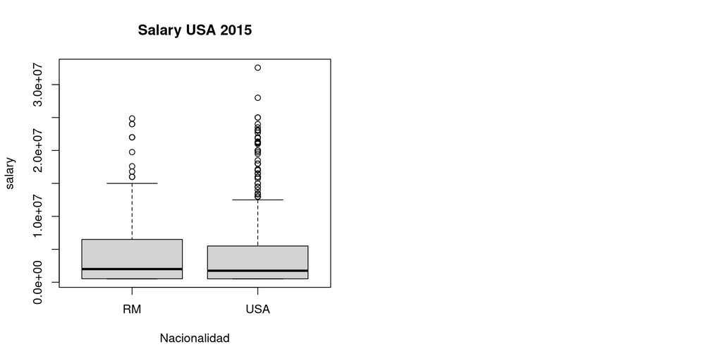

```r
par(mfrow=c(1 ,2))

boxplot(salary~nacionalidad,data=datasetBateadores.2015,main="Salary USA 2015", ylab="salary",xlab="Nacionalidad")
```

Vemos como la variabilidad para los jugadores del 2015 es practicamente igual, lo que confirma los resultados que obtuvimos con respecto al salario entre ambos grupos.

## 5.2 Regresión lineal

Podemos ver que los atributos explicativos del modelo de regresión lineal contribuyen con una parte de la relación lineal con el logaritmo de la varible dependiente, el salario.

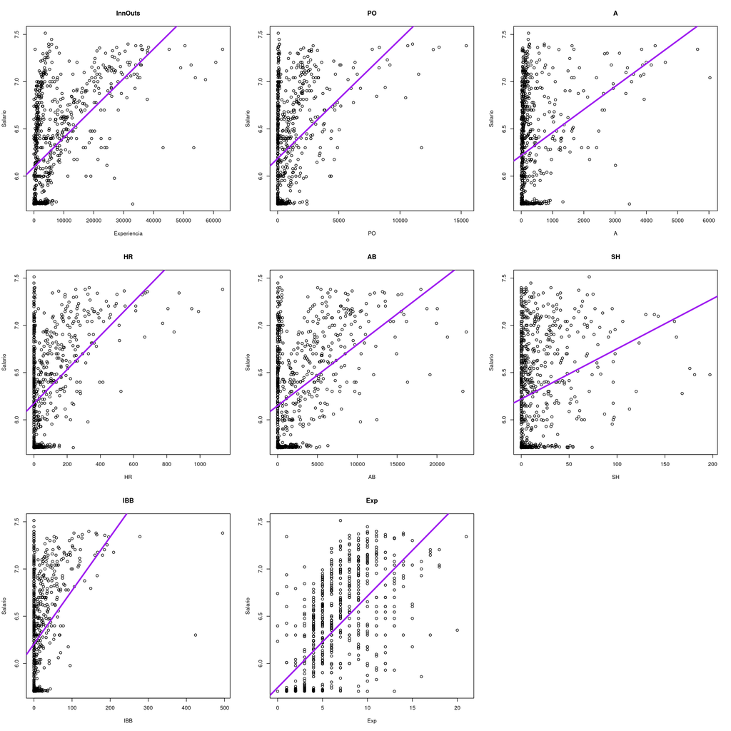

```r
modelo.bat.InnOuts <-lm(log10(salary)~InnOuts,data=datasetBateadores.lm,na.action = na.omit)
sumary<-summary(modelo.bat.InnOuts)
smrs.InnOuts<-sumary$r.squared

modelo.bat.PO <-lm(log10(salary)~PO,data=datasetBateadores.lm,na.action = na.omit)
sumary<-summary(modelo.bat.PO)
smrs.PO<-sumary$r.squared

modelo.bat.A <-lm(log10(salary)~A,data=datasetBateadores.lm,na.action = na.omit)
sumary<-summary(modelo.bat.A)
smrs.A<-sumary$r.squared

modelo.bat.HR <-lm(log10(salary)~HR,data=datasetBateadores.lm,na.action = na.omit)
sumary<-summary(modelo.bat.HR)
smrs.HR<-sumary$r.squared

modelo.bat.AB <-lm(log10(salary)~AB,data=datasetBateadores.lm,na.action = na.omit)
sumary<-summary(modelo.bat.AB)
smrs.AB<-sumary$r.squared

modelo.bat.SH <-lm(log10(salary)~SH,data=datasetBateadores.lm,na.action = na.omit)
sumary<-summary(modelo.bat.SH)
smrs.SH<-sumary$r.squared

modelo.bat.IBB <-lm(log10(salary)~IBB,data=datasetBateadores.lm,na.action = na.omit)
sumary<-summary(modelo.bat.IBB)
smrs.IBB<-sumary$r.squared

modelo.bat.Exp <-lm(log10(salary)~Exp,data=datasetBateadores.lm,na.action = na.omit)
sumary<-summary(modelo.bat.Exp)
smrs.Exp<-sumary$r.squared


par(mfrow=c(3 ,3))

plot(datasetBateadores.lm$InnOuts,log10(datasetBateadores.lm$salary),xlab="Experiencia",ylab="Salario",main="InnOuts")
text(170, 100, labels = round(smrs.InnOuts ,2), col = "blue")
abline(modelo.bat.InnOuts,lwd = 3,col="purple")

plot(datasetBateadores.lm$PO,log10(datasetBateadores.lm$salary),xlab="PO",ylab="Salario",main="PO")
text(170, 100, labels = round(smrs.PO ,2), col = "blue")
abline(modelo.bat.PO,lwd = 3,col="purple")

plot(datasetBateadores.lm$A,log10(datasetBateadores.lm$salary),xlab="A",ylab="Salario",main="A")
text(170, 100, labels = round(smrs.A ,2), col = "blue")
abline(modelo.bat.A,lwd = 3,col="purple")

plot(datasetBateadores.lm$HR,log10(datasetBateadores.lm$salary),xlab="HR",ylab="Salario",main="HR")
text(170, 100, labels = round(smrs.HR ,2), col = "blue")
abline(modelo.bat.HR,lwd = 3,col="purple")

plot(datasetBateadores.lm$AB,log10(datasetBateadores.lm$salary),xlab="AB",ylab="Salario",main="AB")
text(170, 100, labels = round(smrs.AB ,2), col = "blue")
abline(modelo.bat.AB,lwd = 3,col="purple")

plot(datasetBateadores.lm$SH,log10(datasetBateadores.lm$salary),xlab="SH",ylab="Salario",main="SH")
text(170, 100, labels = round(smrs.SH ,2), col = "blue")
abline(modelo.bat.SH,lwd = 3,col="purple")

plot(datasetBateadores.lm$IBB,log10(datasetBateadores.lm$salary),xlab="IBB",ylab="Salario",main="IBB")
text(170, 100, labels = round(smrs.IBB ,2), col = "blue")
abline(modelo.bat.IBB,lwd = 3,col="purple")

plot(datasetBateadores.lm$Exp,log10(datasetBateadores.lm$salary),xlab="Exp",ylab="Salario",main="Exp")
text(170, 100, labels = round(smrs.Exp ,2), col = "blue")
abline(modelo.bat.Exp,lwd = 3,col="purple")
```

## 5.3 Proporción de jugadores USA y RM

Vamos a calcular las tablas de frecuencias para posteriormente representarlas

```r
prop.bat.yr <- table(datasetBateadores.M2000$nacionalidad, datasetBateadores.M2000$yearID)
prop.bat.yr <-round(prop.table(x=prop.bat.yr),3)
prop.bat.yr
```

```
##
##        2000  2001  2002  2003  2004  2005  2006  2007  2008  2009  2010  2011
##   RM  0.014 0.016 0.017 0.017 0.017 0.018 0.017 0.018 0.018 0.017 0.017 0.017
##   USA 0.048 0.047 0.046 0.045 0.045 0.044 0.044 0.045 0.045 0.044 0.045 0.046
##
##        2012  2013  2014  2015
##   RM  0.018 0.018 0.017 0.017
##   USA 0.046 0.045 0.045 0.046
```

Representamos estas proporciones y vemos que las proporciones no tienen cambios significativos a lo largo de estos 15 años.

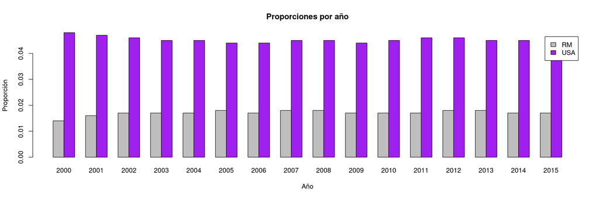

```r
barplot(prop.bat.yr, main="Proporciones por año", xlab="Año", ylab="Proporción", col=c("gray","purple"),
        legend = rownames(prop.bat.yr),   beside=TRUE)
```

# 6 ¿cuáles son las conclusiones? ¿Los resultados permiten responder al problema?

La conclusión principal es la importancia de realizar un proceso completo, donde se parte de una correcta selección de datos y atributos, el estudio de los valores perdidos y outliers y elegir bien la mejor estrategia de imputación en cada caso, esto permite una mejor aplicación de los diferentes análisis que se decidan hacer posteriormente.

En nuestro caso realizamos tres análisis diferentes basados en nuestros datos.

En primer lugar, quisimos demostrar que para el 2015 los jugadores nacidos en USA y en el Resto del Mundo RM, cobraban igual y después de realizar una prueba de hipótesis, pudimos contestar a la pregunta planteada y efectivamente cobran igual.

Posteriormente, quisimos averiguar, si los atributos de juego podían explicar el salario de los jugadores y concluimos, tras realizar numerosas pruebas, que estos podían explicar la variabilidad del logaritmo del salario en un 57%.

Finalmente, queríamos conocer, si la proporción de jugadores del RM había variado significativamente desde el año 2000 al 2015 y mediante un contraste de hipótesis, concluimos que eran significativamente iguales.

Por lo tanto, nuestros datos contestaron a nuestras preguntas.